# Reproducible Research Assignment 1

Sugeet-m

2025-04-24

## Activity Monitoring Data

### Step 1

Setting up the work environment and sourcing the data.

```r
knitr::opts_chunk$set(echo = TRUE)

library(dplyr)
```

```r
library(ggplot2)

fileurl <- "https://d396qusza40orc.cloudfront.net/repdata%2Fdata%2Factivity.zip"
download.file(fileurl, destfile = "./data.zip", method = "curl")
unzip("./data.zip", exdir = "./")
```

### Step 2

Reading the data and examining the contents.

```r
list.files()
```

```
## [1] "activity.csv"                 "activity.zip"
## [3] "data.zip"                     "doc"
## [5] "instructions_fig"             "PA1_template.html"
## [7] "PA1_template.Rmd"             "README.md"
## [9] "ReproducibleData_Peer1.Rproj"
```

```r
data <- read.csv("activity.csv")
str(data)
```

```
## 'data.frame':    17568 obs. of  3 variables:
##  $ steps   : int  NA NA NA NA NA NA NA NA NA NA ...
##  $ date    : chr  "2012-10-01" "2012-10-01" "2012-10-01" "2012-10-01" ...
##  $ interval: int  0 5 10 15 20 25 30 35 40 45 ...
```

### Step 3

Calculating the daily mean and median number of steps and plotting the histogram.

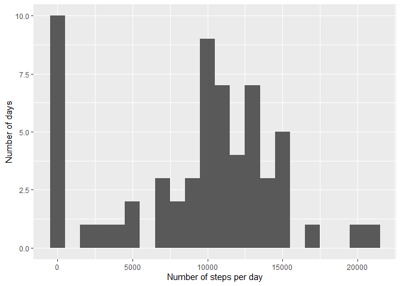

```r
data$date <- as.POSIXlt(data$date) ## needed to group by date
daily <- data %>% group_by(date) %>%
        summarize(DailySteps = sum(steps, na.rm = TRUE))
g <- ggplot(data = daily, aes(x = DailySteps))
g + geom_histogram(binwidth = 1000) +
    labs(x = "Number of steps per day", y = "Number of days")
```

```r
meansteps <- mean(daily$DailySteps)
mediansteps <- median(daily$DailySteps)
```

The daily mean and median number of steps are 9354.2295082 and 10395, respectively.

### Step 4

Plotting the average of the number of steps in each 5-minute interval to highlight any patterns in activity and reporting the interval with the maximum average number of steps.

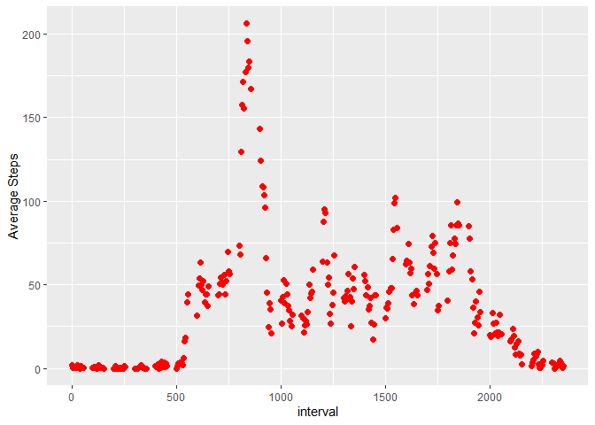

```r
interval <- data %>% group_by(interval) %>%
    summarize(int_av = mean(steps, na.rm = TRUE))
g2 <- ggplot(data = interval, aes(x = interval, y = int_av))
g2 + geom_point(color = "red", cex = 2) +
    labs(x = "interval", y = "Average Steps")
```

```r
minutes <- data %>% group_by(interval) %>%
    summarize(AverageSteps = sum(steps, na.rm = TRUE))
fiveminute <- as.character(minutes[which.max(minutes$AverageSteps),1])
```

The interval with the highest number of average steps is 835.

### Step 5

Examining source data for missing values and imputing missing data.

```r
missingvalues <- sum(is.na(data$steps))
```

The number of missing values in the dataset is 2304.

The data were examined to assess if there were any patterns in the missing data. It was found that the data were missing for entire days. For readability of the documents, the other lines of investigation are not presented.

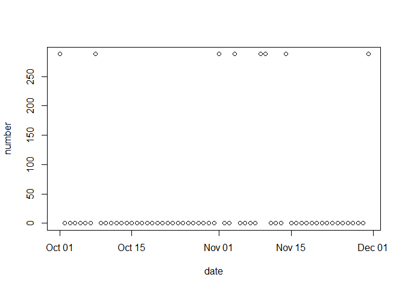

```r
missingdates <- data %>% group_by(date) %>%
    summarize(number = sum(is.na(steps)))
plot(missingdates)
```

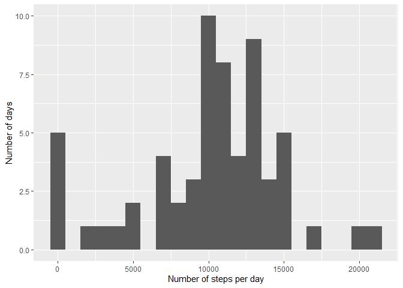

```r
imputed_data <- data

for(i in 1:17280)
{   if(is.na(imputed_data[i,1]))
    {   j <- i+288
        k <- 1+576
        if(!is.na(imputed_data[j,1]))
        {   imputed_data[i,1] <- imputed_data[j,1]
        }
        else
        {   imputed_data[i,1] <- imputed_data[k,1]
        }
    }
}

for(i in 17281:17568)
{   l <- i-288
    imputed_data[i,1] <- imputed_data[l,1]
}

imputed_daily <- imputed_data %>% group_by(date) %>%
    summarize(DailySteps = sum(steps))

g3 <- ggplot(data = imputed_daily, aes(x = DailySteps))
g3 + geom_histogram(binwidth = 1000) +
    labs(x = "Number of steps per day", y = "Number of days")
```

### Step 6

Examining differences in activity between weekdays and weekends. For this analysis, the original dataset (without imputed values) was used.

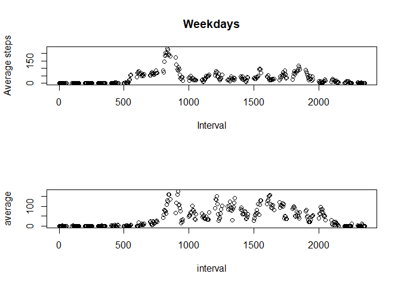

```r
library(timeDate)
dayofweek <- data

dayofweek$date <- as.Date(dayofweek$date) ## required to use timeDate::isWeekend
dayofweek$IsWeekend <- isWeekend(dayofweek$date)

weekdays <- subset(dayofweek, IsWeekend == 0)
weekends <- subset(dayofweek, IsWeekend == 1)

weekdays_av <- weekdays %>% group_by(interval) %>%
    summarize(average = mean(steps, na.rm = TRUE))
weekends_av <- weekends %>% group_by(interval) %>%
    summarize(average = mean(steps, na.rm = TRUE))

par(mfrow = c(2,1))
plot(weekdays_av, xlab = "Interval", ylab = "Average steps", main = "Weekdays")
plot(weekends_av)
```

From this panel plot, it can be seen that there some clear differences between the activity patterns for weekdays and weekends. For example, activity increases more slowly in the morning and continues later into the evening on weekends compared to weekdays.